# Problema 1 - Checkpoint 1

Marcos Antonio Silva Nascimento (marcos.nascimento@ccc.ufcg.edu.br)

19 de maio de 2017

```r
library("dplyr")
library("tidyr")
library("ggplot2")
library("readr")
dados = read_csv(file = "../dados/series_from_imdb.csv")
dados = dados %>% filter(series_name %in% c("13 Reasons Why", "Sense8", "Black Mirror"))
```

# `Sense8`

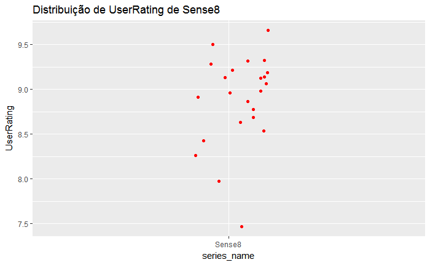

```r
dados %>%
  filter(series_name == "Sense8") %>%
    ggplot(aes(x = series_name, y = UserRating)) +
    geom_jitter(width = .1, color = "red") +
  labs(title = "Distribuição de UserRating de Sense8")
```

Podemos perceber que segundo a classificacao de usuarios IMDB Sense8 tem apenas um valor estranho. Existe pouca variação e dentre os valores frequentes tem a classificação 9 como podemos ver no histograma abaixo.

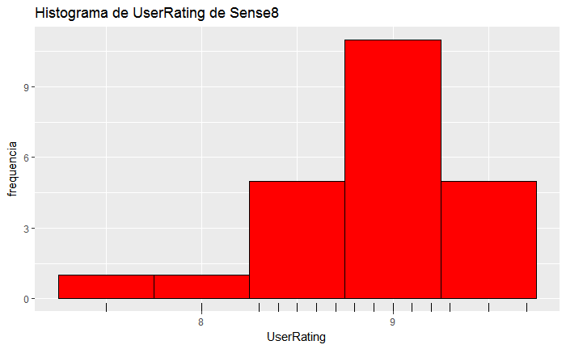

```r
dados %>%
  filter(series_name == "Sense8") %>%
    ggplot(aes(x = UserRating)) +
    geom_histogram(binwidth = .5, fill = "red", color = "black") +
    geom_rug() +
  labs(title = "Histograma de UserRating de Sense8", y = "frequencia")
```

Como a frequência da classificação 9 é maior então espera-se que a mediana seja 9 também, logo, a média(8.9) é representativa da distribuição de classificação de Sense8.

```r
median((dados %>%  filter(series_name == "Sense8"))$UserRating)
```

```
[1] 9
```

```r
mean((dados %>%  filter(series_name == "Sense8"))$UserRating)
```

```
[1] 8.891304
```

Podemos também observar a distribuição de classificação por temporada de Sense8. A segunda temporada é melhor classificada se comparada a primeira temporada, em termos de mediana, e a variação da classificação da primeira foi maior do que na segunda.

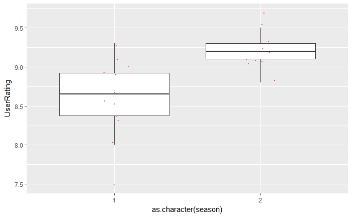

```r
dados %>%  filter(series_name == "Sense8") %>%
    ggplot(aes(x = as.character(season), y = UserRating)) +
    geom_boxplot(outlier.color = NA) +
    geom_jitter(width = .1, size = .5, alpha = .5, color = "red")
```

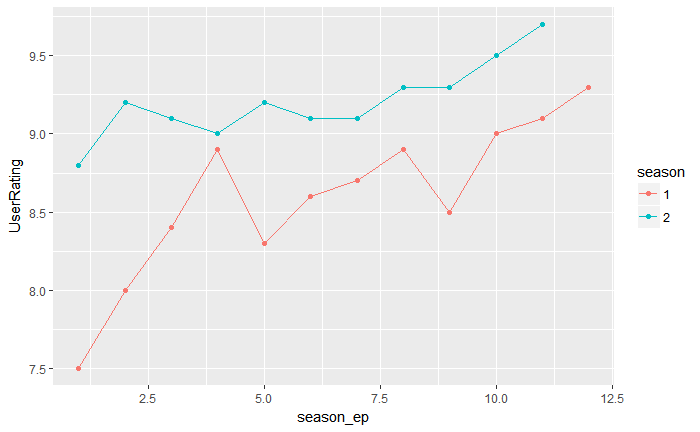

```r
dados %>%  filter(series_name == "Sense8") %>%
  mutate(season = as.character(season)) %>%
  ggplot(aes(x = season_ep, y = UserRating, color = season)) +
  geom_line() +
  geom_point()
```

Podemos ainda verificar a existência de uma correlação entre o episódio da série e sua classificação e podemos perceber que a mesma existe. Existe uma correlação linear forte entre essas duas variáveis, ou seja, o episódio da série influencia diretamente na classificação do episódio e virse e versa.

```r
dados %>%  filter(series_name == "Sense8") %>%
    group_by(season) %>%
    summarise(correlacao_linear = cor(season_ep, UserRating,
                                      method = "pearson"),
              correlacao_kendall = cor(season_ep, UserRating,
                                       method = "kendall"))
```

| season | correlacao_linear | correlacao_kendall |
| --- | --- | --- |
| 1 | 0.8445778 | 0.7481134 |
| 2 | 0.8447368 | 0.6864931 |

# `Black Mirror`

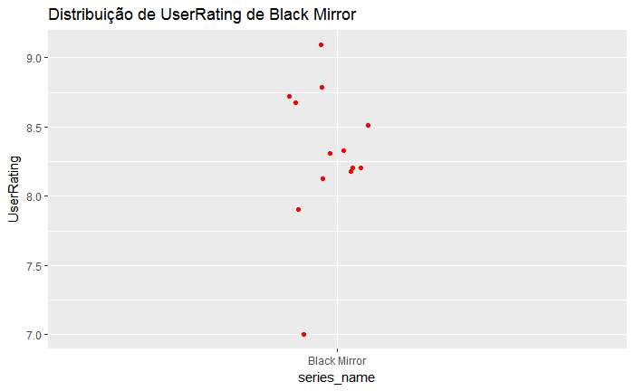

```r
dados %>%
  filter(series_name == "Black Mirror") %>%
    ggplot(aes(x = series_name, y = UserRating)) +
    geom_jitter(width = .1, color = "red") +
  labs(title = "Distribuição de UserRating de Black Mirror")
```

Podemos perceber que segundo a classificacao de usuarios IMDB Black Mirror tem apenas um valor estranho. Existe pouca variação e dentre os valores frequentes temos as classificações de 8.0 e 8.5 como podemos ver no histograma abaixo.

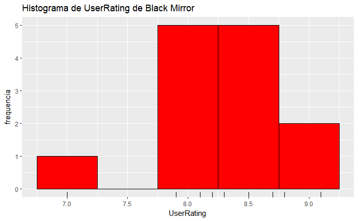

```r
dados %>%
  filter(series_name == "Black Mirror") %>%
    ggplot(aes(x = UserRating)) +
    geom_histogram(binwidth = .5, fill = "red", color = "black") +
    geom_rug() +
  labs(title = "Histograma de UserRating de Black Mirror", y = "frequencia")
```

Como a frequência da classificação concentra-se em 8.0 e 8.5 então espera-se que a mediana esteja neste entorno. Neste caso, houve a coincidência da mediana e da média, 8.3, que também é representativa da distribuição de classificação de Black Mirror.

```r
median((dados %>%  filter(series_name == "Black Mirror"))$UserRating)
```

```
[1] 8.3
```

```r
mean((dados %>%  filter(series_name == "Black Mirror"))$UserRating)
```

```
[1] 8.307692
```

Podemos também observar a distribuição de classificação por temporada de Black Mirror. A terceira temporada é melhor classificada se comparada a primeira e a segunda temporada, em termos de mediana, e a variação da classificação da segunda temporada foi maior do que na primeira e terceira. Pode-se observar também que a temporada com menor classificação dentre as 3 foi a segunda temporada.

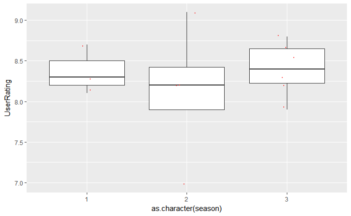

```r
dados %>%  filter(series_name == "Black Mirror") %>%
    ggplot(aes(x = as.character(season), y = UserRating)) +
    geom_boxplot(outlier.color = NA) +
    geom_jitter(width = .1, size = .5, alpha = .5, color = "red")
```

Com o passar dos episódios de Black Mirror a única temporada que a classificação só subiu foi a primeira, enquanto que na segunda e terceira temporada vemos uma variação da classificação. Dentre as variações a temporada que mais variou a classificação sendo a segunda temporada (clasificações de 7 até ~9).

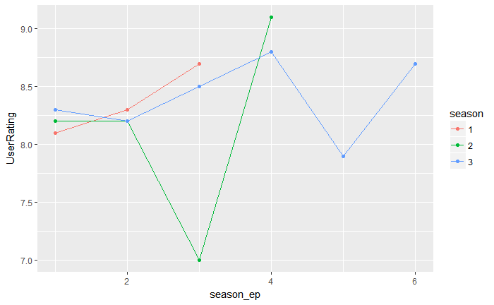

```r
dados %>%  filter(series_name == "Black Mirror") %>%
  mutate(season = as.character(season)) %>%
  ggplot(aes(x = season_ep, y = UserRating, color = season)) +
  geom_line() +
  geom_point()
```

Quanto a correlação entre o episódio da série e sua classificação e podemos perceber que a existência de uma correlação linear forte entre essas duas variáveis apenas na primeira temporada.

```r
dados %>%  filter(series_name == "Black Mirror") %>%
    group_by(season) %>%
    summarise(correlacao_linear = cor(season_ep, UserRating,
                                      method = "pearson"),
              correlacao_kendall = cor(season_ep, UserRating,
                                       method = "kendall"))
```

| season | correlacao_linear | correlacao_kendall |
| --- | --- | --- |
| 1 | 0.9819805 | 1.0000000 |
| 2 | 0.2247333 | 0.1825742 |
| 3 | 0.2236068 | 0.2000000 |

# `13 Reasons Why`

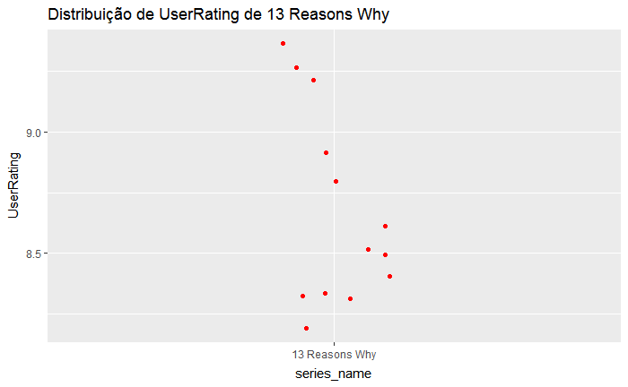

```r
dados %>%
  filter(series_name == "13 Reasons Why") %>%
    ggplot(aes(x = series_name, y = UserRating)) +
    geom_jitter(width = .1, color = "red") +
  labs(title = "Distribuição de UserRating de 13 Reasons Why")
```

Podemos perceber que segundo a classificacao de usuarios IMDB 13 Reasons Why não possui valores estranhos. Existe pouca variação e dentre os valores frequentes temos as classificações de 8.5 como podemos ver no histograma abaixo.

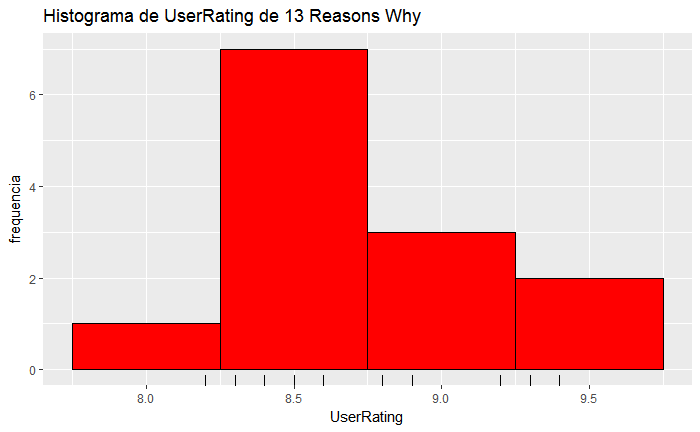

```r
dados %>%
  filter(series_name == "13 Reasons Why") %>%
    ggplot(aes(x = UserRating)) +
    geom_histogram(binwidth = .5, fill = "red", color = "black") +
    geom_rug() +
  labs(title = "Histograma de UserRating de 13 Reasons Why", y = "frequencia")
```

Como a frequência da classificação concentra-se em 8.5 então espera-se que a mediana esteja neste entorno. Neste caso, quase houve a coincidência da mediana(8.5) e da média(8.669231), o que faz com que essas métricas sejam representativas da distribuição de classificação de 13 Reasons Why.

```r
median((dados %>%  filter(series_name == "13 Reasons Why"))$UserRating)
```

```
[1] 8.5
```

```r
mean((dados %>%  filter(series_name == "13 Reasons Why"))$UserRating)
```

```
[1] 8.669231
```

Podemos também observar a distribuição de classificação por temporada de 13 Reasons Why. A primeira temporada, única presente nos dados, tem classificação em termos de mediana de 8.5.

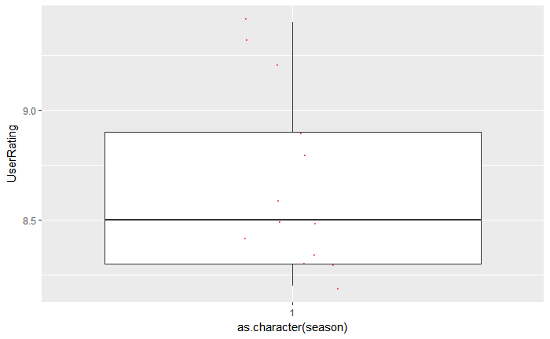

```r
dados %>%  filter(series_name == "13 Reasons Why") %>%
    ggplot(aes(x = as.character(season), y = UserRating)) +
    geom_boxplot(outlier.color = NA) +
    geom_jitter(width = .1, size = .5, alpha = .5, color = "red")
```

Com o passar dos episódios de 13 Reasons Why da primeira temporada a classificação só subiu apesar de variar ao mesmo tempo.

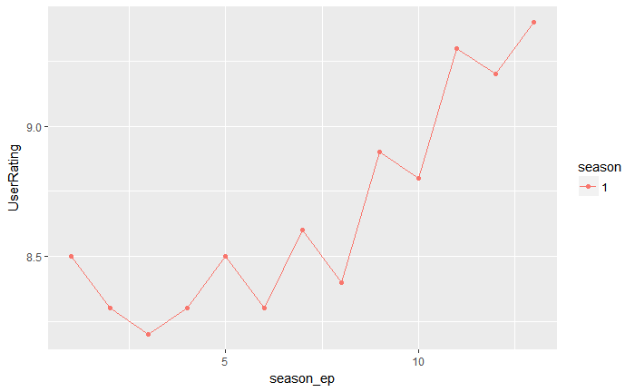

```r
dados %>%  filter(series_name == "13 Reasons Why") %>%
  mutate(season = as.character(season)) %>%
  ggplot(aes(x = season_ep, y = UserRating, color = season)) +
  geom_line() +
  geom_point()
```

```r
dados %>%  filter(series_name == "13 Reasons Why") %>%
    group_by(season) %>%
    summarise(correlacao_linear = cor(season_ep, UserRating,
                                      method = "pearson"),
              correlacao_kendall = cor(season_ep, UserRating,
                                       method = "kendall"))
```

| season | correlacao_linear | correlacao_kendall |
| --- | --- | --- |
| 1 | 0.8650644 | 0.6844476 |

# `Perguntas`

**Qual das series que voce escolheu e mais bem avaliada no IMDB? A diferenca e grande? Pequena?**

Aparentemente a serie mais bem avaliada e a Sense8 se observar-mos o grafico de dispersao e levarmos em consideração a classificação do usuário (UserRating) e a mediana como métrica de comparação.

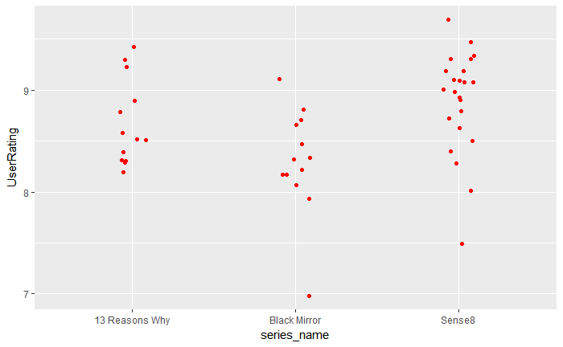

```r
dados %>%
    ggplot(aes(x = series_name, y = UserRating)) +
    geom_jitter(width = .1, color = "red")
```

Para observar melhor qual delas e mais bem avaliada segundo o UserRating ou classificacao do usuario vamos olhar para o grafico de box plot de cada uma das series.

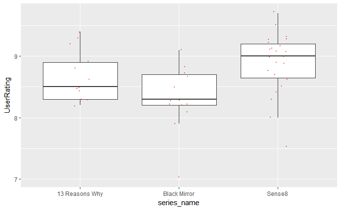

```r
dados %>%
    ggplot(aes(x = series_name, y = UserRating)) +
    geom_boxplot(outlier.color = NA) +
    geom_jitter(width = .1, size = .5, alpha = .5, color = "red")
```

Olhando para o grafico podemos usar como metrica de avaliacao a mediana das classificacoes dos usuarios, desta forma fica claro que Sense8 e a serie mais bem avaliada com relacao as demais. A mediana e uma boa metrica porque ajuda a perceber onde fica a maior concentracao de avaliacoes daquela serie diminuindo o vies de outliers. Ainda sobre a diferenca de cada uma das series vemos que a mediana de todas as series esta entre 8 e 9 sendo pequena a diferenca das avaliacoes entre 13 Reasons Why e Black Mirror e grande entre Sense8 e 13 Reasons Why e Sense8 e Black Mirror como vemos no gráfico.

**Qual das series que voce escolheu tem episodios de qualidade mais irregular segundo o IMDB? A diferenca e grande? Pequena?**

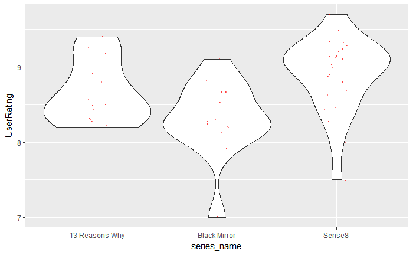

```r
dados %>%
    ggplot(aes(x = series_name, y = UserRating)) +
    #geom_boxplot(outlier.color = NA) +
    geom_violin() +
    geom_jitter(width = .1, size = .5, alpha = .5, color = "red")
```